# A3: Incarceration

### Introduction

An introduction of the problem domain and a description of the variable(s) you are choosing to analyze (and why!)

Incarceration in the United States is a critical social issue with significant disparities across different racial, gender, and geographical groups. This report aims to analyze these disparities using comprehensive datasets on incarceration rates. We will focus on variables such as incarceration rates by race, gender, and location to understand how these measures vary across different groups.

### Summary Information

Write a summary paragraph of findings that includes the 5 values calculated from your summary information R script

These will likely be calculated using your DPLYR skills, answering questions such as:

- What is the average value of my variable across all the counties (in the current year)?
- Where is my variable the highest / lowest?
- How much has my variable change over the last N years?

Feel free to calculate and report values that you find relevant. Again, remember that the purpose is to think about how these measure of incarceration vary by race.

```
## [1] 317.8509
```

```
## [1] 51021.86
```

```
## [1] 0
```

```
## [1] 502.077
```

```
## # A tibble: 1 × 5
##   white_mean_rate black_mean_rate latinx_mean_rate aapi_mean_rate
##             <dbl>           <dbl>            <dbl>          <dbl>
## 1            163.            247.             101.           7.35
## # ℹ 1 more variable: native_mean_rate <dbl>
```

Based on the value have been calculated, mean incarceration rate = 317.8509, max incarceration rate = 51021.86, min incarceration rate = 0, change incarceration rate = 502.077, and the racial group rate show in the table above.

### The Dataset

#### Who collected the data?

The datasets used in this analysis were collected by various organizations and researchers dedicated to understanding incarceration trends in the United States. Specifically, the data is often gathered from government agencies such as the Bureau of Justice Statistics (BJS) and other related institutions that maintain records on prison and jail populations.

#### How was the data collected or generated?

The data was collected through official records and surveys conducted by these agencies. These records typically include counts of the incarcerated population, demographic information, and other relevant statistics. The surveys and data collection efforts are usually conducted periodically to track changes over time and to provide a comprehensive view of incarceration trends.

#### Why was the data collected?

The primary purpose of collecting this data is to analyze and understand trends in incarceration rates, with a focus on identifying disparities across different demographic groups. This data helps policymakers, researchers, and advocacy groups to address issues related to criminal justice, such as racial and gender disparities in incarceration, the impact of incarceration on communities, and the effectiveness of different criminal justice policies.

When working with incarceration data, several ethical questions and questions of power must be considered. One significant concern is the privacy and confidentiality of the individuals represented in the dataset. While the data is typically anonymized, it still represents sensitive information about people’s interactions with the criminal justice system. Additionally, there is a risk of stigmatizing certain groups if the data is not presented or interpreted carefully. Researchers must be cautious to avoid reinforcing stereotypes or biases, particularly when analyzing disparities across racial and ethnic groups.

#### What, if any, ethical questions or questions of power do you need to consider when working with this data?

Another ethical consideration is the potential for the data to be used to justify punitive policies rather than rehabilitative ones. Data can be a powerful tool for advocacy, but it can also be misused to support policies that may not address the root causes of crime and incarceration, such as poverty, lack of education, and systemic discrimination.

#### What are possible limitations or problems with this data? (at least 200 words)

Possible limitations of the data include incomplete data for some counties or demographic groups, potential biases in data collection methods, and changes in data collection procedures over time. These limitations can affect the accuracy and comparability of the data, making it essential for researchers to use caution when drawing conclusions and making policy recommendations based on the data.

### Trends Over Time Chart

Include a chart. Make sure to describe why you included the chart, and what patterns emerged

The first chart that you will create and include will show the trend over time of your variable/topic. Think carefully about what you want to communicate to your user (you may have to find relevant trends in the dataset first!). Here are some requirements to help guide your design:

- Show more than one, but fewer than ~10 trends
  - This may mean showing the same measure for different locations or different racial groups. Think carefully about a meaningful comparison of locations (e.g., the top 10 counties in a state, top 10 states, etc.)
- You must have clear x and y axis labels
- The chart needs a clear title
- You need a legend for your different line colors and a clear legend title

When we say “clear” or “human readable” titles and labels, that means that you should not just display the variable name.

Here’s an example of how to run an R script inside an RMarkdown file:

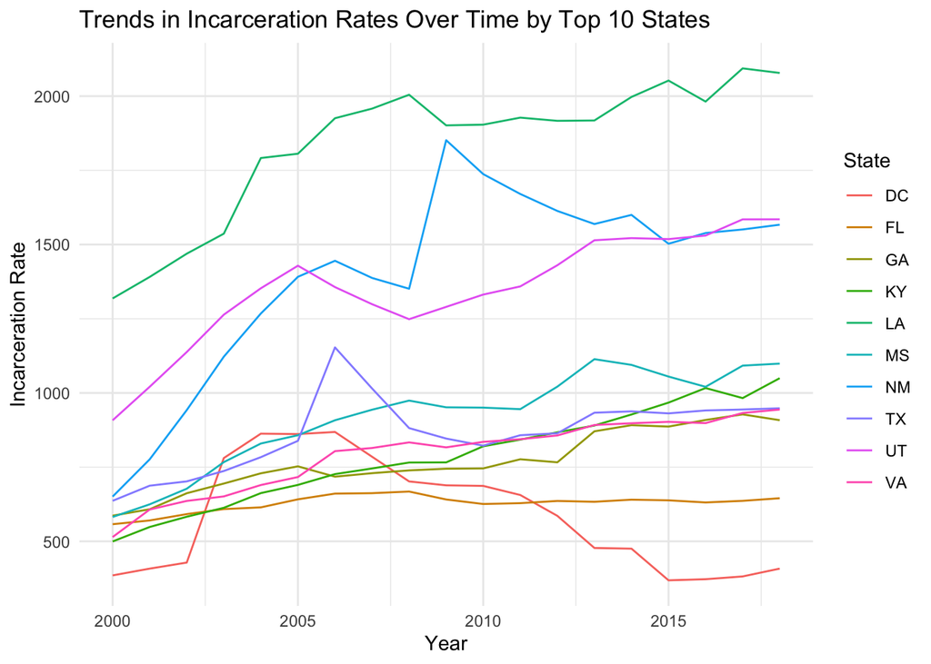

I included this chart to visualize trends in incarceration rates over time for the top 10 states with the highest average incarceration rates, providing a focused view of significant trends. The chart shows a general increase in incarceration rates, divergence between states, and fluctuations in certain states, highlighting persistent underlying factors and periods of rapid policy changes. This focused approach helps identify states where policy interventions may be most needed.

### Variable Comparison Chart

Include a chart. Make sure to describe why you included the chart, and what patterns emerged

The second chart that you will create and include will show how two different (continuous) variables are related to one another. Again, think carefully about what such a comparison means and what you want to communicate to your user (you may have to find relevant trends in the dataset first!). Here are some requirements to help guide your design:

- You must have clear x and y axis labels
- The chart needs a clear title
- If you choose to add a color encoding (not required), you need a legend for your different color and a clear legend title

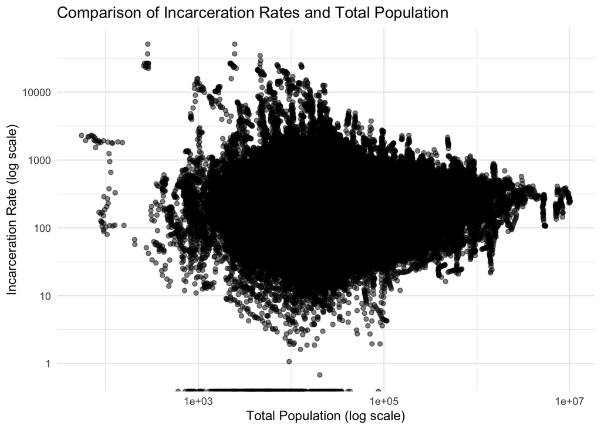

### Map

Include a chart. Make sure to describe why you included the chart, and what patterns emerged

The last chart that you will create and include will show how a variable is distributed geographically. Again, think carefully about what such a comparison means and what you want to communicate to your user (you may have to find relevant trends in the dataset first!). Here are some requirements to help guide your design:

- Your map needs a title
- Your color scale needs a legend with a clear label
- Use a map based coordinate system to set the aspect ratio of your map

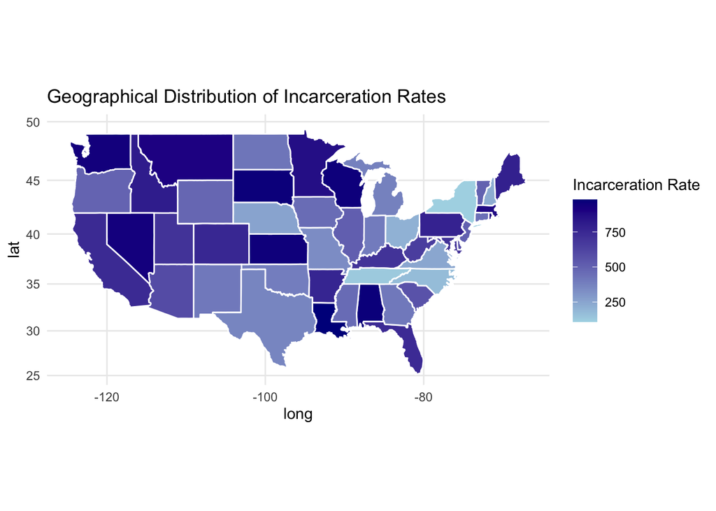

I included this map to visualize how incarceration rates are distributed geographically across the United States. This map helps identify regional patterns and disparities, revealing which states have higher or lower incarceration rates. Patterns that emerged include noticeable variations in incarceration rates, with some regions having significantly higher rates than others, which can inform policymakers and researchers about areas that may require more focused interventions.